# 心理ネットワークモデルと階層モデル

専修大学 国里愛彦

2026-12-07

## 国里愛彦（くにさと よしひこ）

- 専修大学人間科学部心理学科 教授
- 専門：計算論的精神医学、認知行動療法
- COI開示：国里の著書や関連する団体について紹介するが、特定企業との利益相反はない。

## 目次

- 問題設定：なぜ「構造」が問題になるのか 👈️
- 階層モデル：HiTOP・p因子・CB5T
- 心理ネットワークモデル
- 論争：ネットワーク側からの批判
- 論争：階層モデル側からの批判と往復
- 等価性と実証的な比較
- 統合と収束、そして議論

## カテゴリー診断の限界

- DSM のようなカテゴリー診断には、よく知られた問題がある
  - **併存（comorbidity）**：1人が複数の診断を満たすことが多い
  - **異質性**：同じ診断でも症状の組み合わせが大きく異なる
  - **閾値の恣意性**：「5つ以上で診断」の境目に自然な切れ目はない
- DSM-5 の診断基準を症状に分解すると、不眠・集中困難・易怒性など**同じ症状が多くの診断で繰り返し使われている** (Forbes, Neo, et al., 2023)

→ 症状どうしの共変動（相関）をどう説明するか？

## DSM-5 では同じ症状が何度も登場する

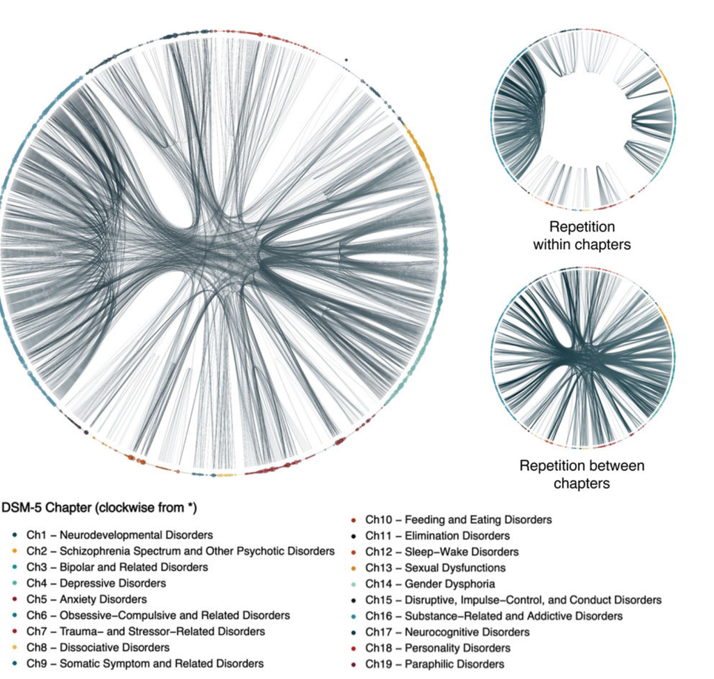

- DSM-5 の診断基準を1419の構成症状に分解し、症状の重複を図示した (Forbes, Neo, et al., 2023, fig. 1)
- 線は、同じ症状が複数の診断で使われていることを表す
- 章（障害群）の中でも、章をまたいでも、重複は多い
- → 症状の重複そのものが「併存」を生みうる

## 共変動の2つの説明

**共通原因（潜在変数）モデル**

- 症状の背後に共通の原因（潜在変数）がある
- 症状が相関するのは、同じ原因から生じているから
- 例：「うつ病」が抑うつ気分・不眠・疲労を引き起こす
- 因子を共通原因と解釈した場合の説明。HiTOP 自体は共変動に基づく分類

**ネットワーク（相互作用）モデル**

- 症状どうしが直接に影響し合う
- 症状が相関するのは、互いに因果的につながっているから
- 例：不眠 → 疲労 → 集中困難 → 自己評価の低下
- → 心理ネットワークモデル

## 共変動の2つの説明（図）

```
flowchart TD
  L((潜在変数)) --> A[症状A]
  L --> B[症状B]
  L --> C[症状C]
  L --> D[症状D]
```

共通原因：症状間の相関は潜在変数で説明され、潜在変数を条件づけると症状どうしは独立になる

```
flowchart LR
  A[症状A] --- B[症状B]
  B --- C[症状C]
  C --- D[症状D]
  A --- C
```

ネットワーク：症状どうしが直接つながり、相関はその連鎖から生じる

## 本日の論争の構図

|  | 階層モデル側 | ネットワーク側 |
| --- | --- | --- |
| 主な研究者 | Krueger, Kotov, Forbes, Wright, Markon, Caspi, Moffitt, DeYoung | Borsboom, Cramer, Fried, Epskamp, van der Maas |
| 基本の発想 | 共変動を要約する次元・階層 | 要素間の相互作用から創発するシステム |
| 代表的な成果 | HiTOP (Kotov et al., 2017)、p因子 (Caspi et al., 2014) | 精神障害のネットワーク理論 (Borsboom, 2017) |
| 相手への主な批判 | ネットワークは再現性が低く、潜在構造を無視している | 一般因子は統計的な産物で、原因の証拠にならない |

## 目次

- 問題設定：なぜ「構造」が問題になるのか
- 階層モデル：HiTOP・p因子・CB5T 👈️
- 心理ネットワークモデル
- 論争：ネットワーク側からの批判
- 論争：階層モデル側からの批判と往復
- 等価性と実証的な比較
- 統合と収束、そして議論

## 反映的潜在変数モデル

- 因子分析・IRT・構造方程式モデルの基本の発想
  - 観測変数（項目・症状）は潜在変数の**結果**であり、潜在変数が観測変数の**原因**である
  - 潜在変数を条件づけると、観測変数どうしは独立になる（局所独立）
- この発想を何段にも重ねたのが**階層モデル**
  - 症状 → 症候群 → スペクトラム → 一般因子
- 潜在変数をどう解釈するかは別の問題
  - 実在する原因とみる（実在論）、便利な要約とみる（道具主義）など (Borsboom et al., 2003)

## HiTOP（精神病理の階層的分類）

- **Hierarchical Taxonomy of Psychopathology** (Kotov et al., 2017, 2021)
- DSM のカテゴリーに代わり、症状の**共変動**に基づいて次元的・階層的に分類する
- 研究者のコンソーシアムによる量的分類（quantitative nosology）(Krueger et al., 2018)
- 研究への活用法も提案されている (Conway et al., 2019)
  - ネットワーク学派の Fried もこの論文の共著者

## HiTOP の階層

| 階層 | 例 |
| --- | --- |
| 超スペクトラム（→ p） | 情動の機能不全、精神病、外在化 |
| スペクトラム | 内在化、身体表現、思考障害、離脱、脱抑制的外在化、敵対的外在化 |
| 下位因子 | 苦痛（distress）、恐怖（fear）、摂食の問題 など |
| 症候群・特性 | うつ病、パニック障害 など |
| 構成要素・症状 | 不眠、抑うつ気分、回避 など |

- 上の階層ほど広く、下の階層ほど細かい
- どの階層で研究するかは目的によって選べる (Kotov et al., 2017, 2021)

## HiTOP の全体像

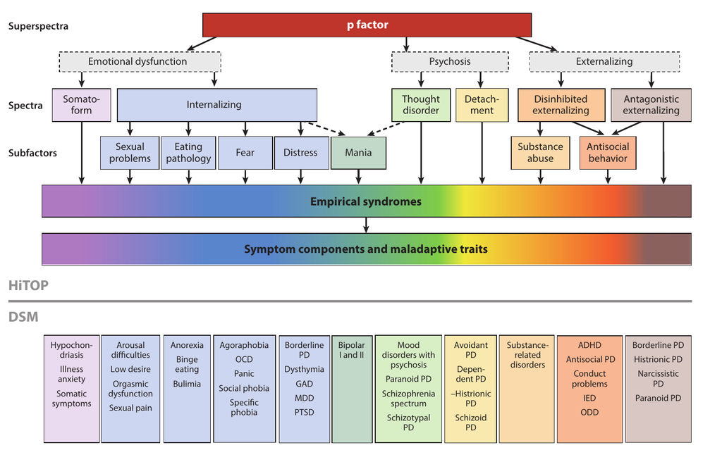

- 上段が HiTOP の階層、下段が対応する DSM の診断。HiTOP は DSM の診断そのものではなく、その症状を組み直している (Kotov et al., 2021, fig. 1)

## p因子（一般精神病理因子）

- Dunedin 縦断研究に双因子モデルを当てはめ、各障害指標に直接負荷する**一般因子 p** を推定した (Caspi et al., 2014)
- p が高い人ほど、生涯にわたる障害・機能低下が大きい
- 「精神疾患を一次元で捉える」見方へ (Caspi & Moffitt, 2018)
- p の意味の候補
  - 否定的情動性、衝動的な反応性、思考の混乱、機能障害 など
  - p は神経症傾向・機能障害・衝動性と強く相関した（r ≈ .87〜.88）(Southward et al., 2023)

## 双因子モデルと高次因子モデル

**高次因子モデル**（図の a）

- 症状 → 一次因子（内在化など） → 二次因子
- 一般因子の影響は一次因子を介して症状に及ぶ（図中の g は一般因子） (van Bork et al., 2017, fig. 1)
- HiTOP の階層はこちらの考え方に近い

**双因子モデル**（図の b）

- 一般因子がすべての症状に直接負荷する
- 特殊因子（内在化など）は一般因子と直交する
- p因子研究の多くはこのモデルを使う

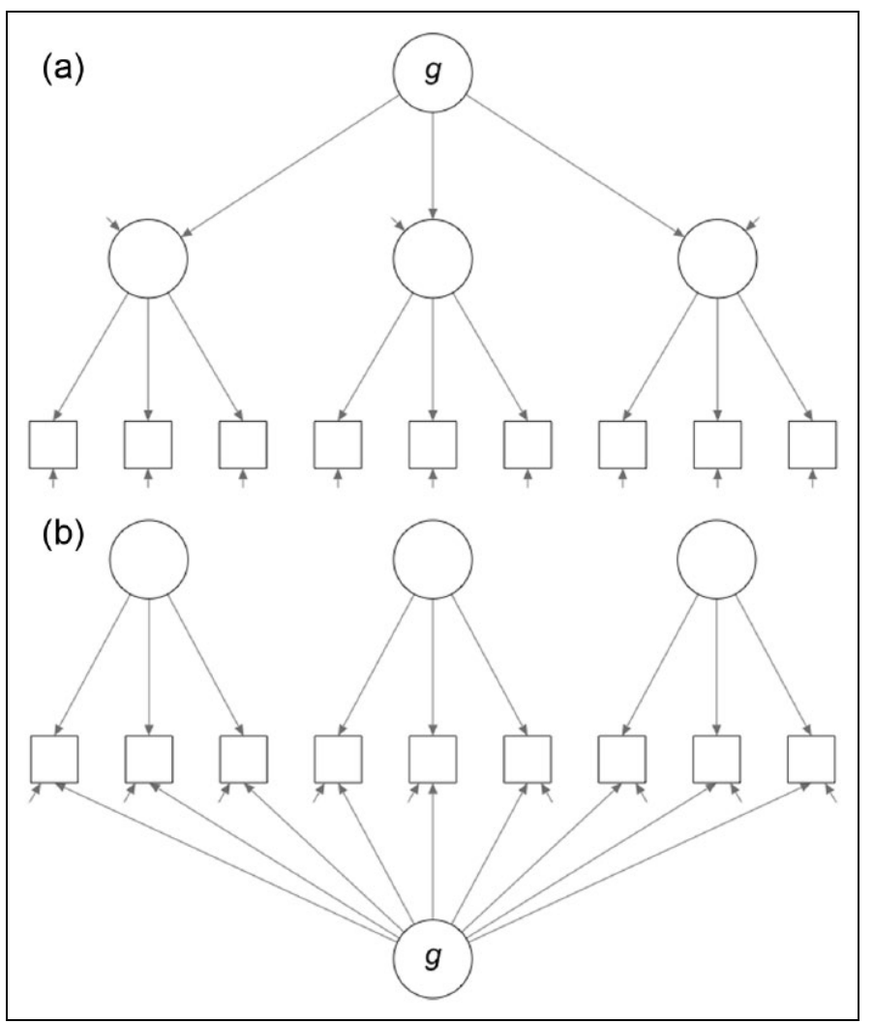

→ どちらのモデルを選ぶかで p の意味も変わる (Caspi et al., 2024)。後でみるように、モデル選択そのものが論争になる

## 性格の階層：Big Five とその上下

- Big Five（神経症傾向、外向性、開放性、協調性、誠実性）も階層的な潜在変数モデル
- 上位の因子（メタ特性）
  - **安定性**（協調性、誠実性、情緒安定性）と**可塑性**（外向性、開放性）(DeYoung, 2006; Digman, 1997)
- 下位の単位
  - 側面（aspect）→ ファセット → 項目（nuance）
  - 項目にも、上位因子に還元できない固有の安定性・遺伝率・予測力がある (Mõttus et al., 2017)

## CB5T（サイバネティックBig Five理論）

- DeYoung による、Big Five を**目標追求の制御システム**として説明する理論 (DeYoung, 2015)
  - 目標を立て、状況を解釈し、行動を選び、結果を評価するサイクル（サイバネティクス）
  - 性格特性 ＝ このサイクルを担う仕組みのパラメータの個人差
- 階層構造を記述するだけでなく、**なぜその次元があるのか**を機能から説明しようとする点が特徴
- 精神病理への拡張：精神病理を、目標に向かって進めない状態が続く「**サイバネティックな機能不全**」として捉える (DeYoung & Krueger, 2018)

## 性格と精神病理の連続性

- HiTOP のスペクトラムは、性格の五因子とよく対応する (Widiger et al., 2019)

| HiTOP のスペクトラム | 性格の五因子 |
| --- | --- |
| 内在化 | 神経症傾向 |
| 離脱 | 低い外向性 |
| 敵対的外在化 | 低い協調性 |
| 脱抑制的外在化 | 低い誠実性 |
| 思考障害 | 開放性（精神病傾向） |

→ 性格と精神病理を同じ階層構造の上で扱える。CB5T はこの構造に機能的な説明を与えようとする

## 性格・パーソナリティ障害・精神病理の次元の対応

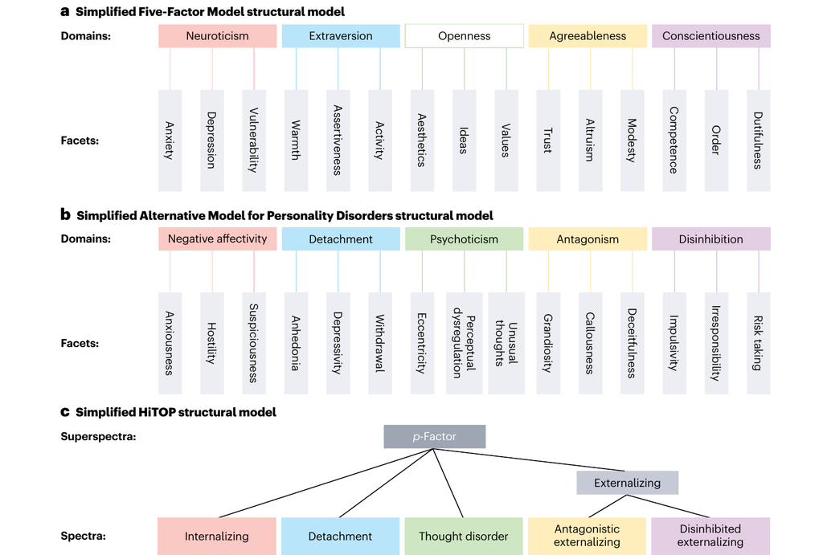

- a：五因子モデル、b：DSM-5 のパーソナリティ障害代替モデル、c：HiTOP。同じ色の次元どうしが対応する (Eaton et al., 2023, fig. 1)

## 階層モデルの強み

- **併存と異質性を同時に扱える**：上位の次元で併存を、下位の次元で異質性を表す
- **信頼性と予測力**：次元的な得点はカテゴリーより信頼性が高く、予後の予測にも役立つ
- **外的妥当性の蓄積**：遺伝、神経、予後、治療反応との関連 (Kotov et al., 2021; Lahey et al., 2021)
- **研究目的に応じて階層を選べる** (Conway et al., 2019)
- 近年は、次元を因果的実体ではなく**実用的・記述的な分類**として位置づける方向 (Krueger, 2025)

## 目次

- 問題設定：なぜ「構造」が問題になるのか
- 階層モデル：HiTOP・p因子・CB5T
- 心理ネットワークモデル 👈️
- 論争：ネットワーク側からの批判
- 論争：階層モデル側からの批判と往復
- 等価性と実証的な比較
- 統合と収束、そして議論

## 心理ネットワークアプローチの源流

- Borsboom による潜在変数モデルの理論的な検討 (Borsboom et al., 2003; Borsboom, 2005)
  - 反映モデルは「潜在変数が指標を生む」という因果的な主張を含む
  - 個人間の構造から、個人内の因果は導けない
- van der Maas による知能の相互作用（mutualism）モデル (H. L. J. Van Der Maas et al., 2006)
  - 認知能力どうしが発達の中で互いに高め合うだけで、正の相関（positive manifold）と一般因子 g が生じる
  - → 「一般因子がある ＝ 共通原因がある」とは言えない

## 併存症のネットワーク説

- 併存は、潜在的な障害どうしの相関ではなく、診断をまたぐ**橋渡し症状**を介した症状間の因果で生じる (Cramer et al., 2010)
  - 例：うつ病と全般性不安障害は、睡眠の問題・疲労・集中困難などを共有している
- DSM-IV の症状は重なり合って**スモールワールド**型のネットワークを作る (Borsboom et al., 2011)
- 症状は障害ごとにクラスターを作るが、境界ははっきりしない (Boschloo et al., 2015)

## 橋渡し症状による併存

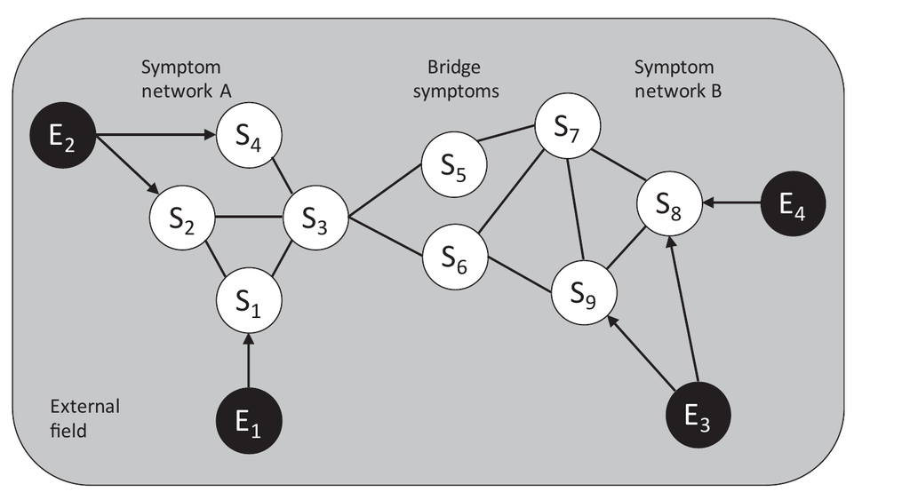

- 障害 A と障害 B の症状ネットワークが、両方に属する橋渡し症状（S5、S6）でつながる。E は外的な出来事（ストレスなど） (Borsboom, 2017, fig. 2)

## うつ病と全般性不安障害のネットワーク

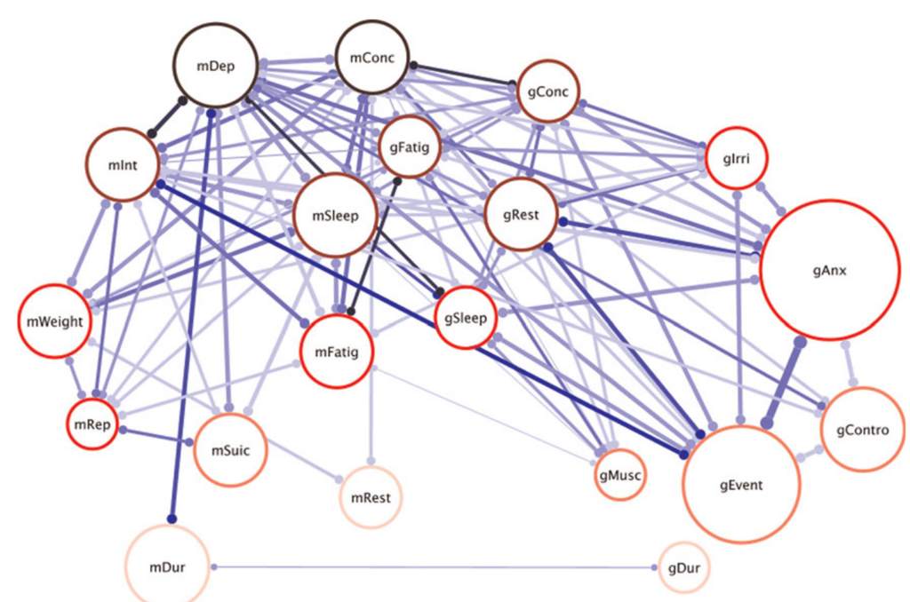

- m＝うつ病の症状、g＝全般性不安障害の症状。中央にある睡眠・疲労・集中困難・落ち着きのなさは両方の診断に含まれる重複症状 (Cramer et al., 2010, fig. 4)

## DSM-IV の症状ネットワーク

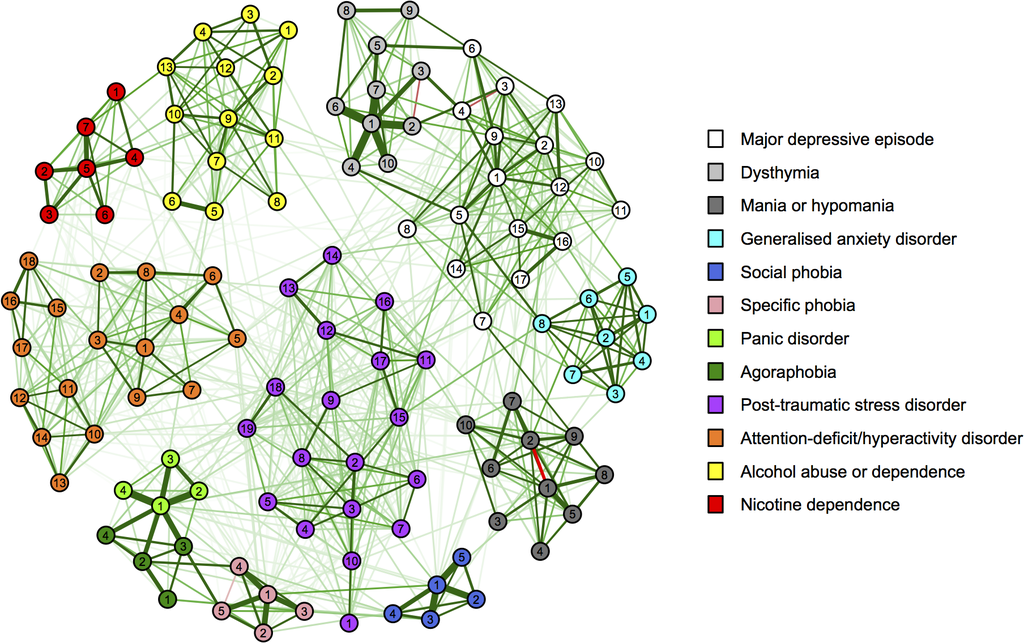

Boschloo et al. (2015)

## 精神障害のネットワーク理論

- 障害は症状の背後にある原因ではなく、症状ネットワークの**安定した状態そのもの** (Borsboom, 2017; Borsboom & Cramer, 2013)
- 理論の要素
  - 症状どうしの因果的なつながり
  - 外的な出来事（ストレスなど）がネットワークを活性化する
  - つながりが強いと、きっかけが消えても症状が持続する（**ヒステリシス**）
  - 健康な状態と障害の状態という**2つの安定状態**がありうる
- 精神疾患には中心的な病因経路がなく、システムとして捉えるしかない (Borsboom, Haslbeck, et al., 2022; Fried & Robinaugh, 2020)

## 精神障害が発症するまでの4つの段階

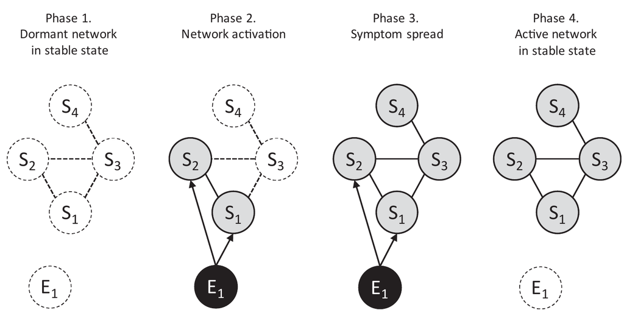

1. 休眠中のネットワーク 2. 外的な出来事（E1）による活性化 3. 症状の広がり 4. 出来事が消えても活性化したまま安定する (Borsboom, 2017, fig. 3)

## レジリエンスと脆弱性

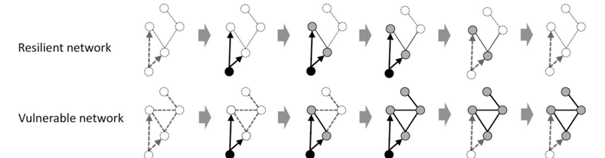

- **つながりの弱いネットワーク**（上段）：出来事で症状が出ても、出来事が消えれば元に戻る（レジリエント）
- **つながりの強いネットワーク**（下段）：症状どうしが活性化し合い、出来事が消えても症状が続く（脆弱） (Borsboom, 2017, fig. 4)

## 心理ネットワークモデル（統計モデル）

- 多変量確率分布を使って、変数間のネットワーク構造を描く (Epskamp et al., 2018)
  - ノード ＝ 観測変数（症状・項目）
  - エッジ ＝ 他のすべての変数で条件づけた関連（偏相関など）
- 代表的なモデル：ガウシアン・グラフィカル・モデル（GGM）、Ising モデル
- 推定と精度の検証手順も整備されている (Epskamp et al., 2018)
- 入門書 (Isvoranu et al., 2022)、標準的な解説 (Borsboom et al., 2021)

## 性格もネットワークとして

- Big Five を項目の共通原因とする見方を批判し、性格次元は**項目間の相互作用が平衡に落ち着いた結果**だと主張した (Cramer et al., 2012a)
  - 副題 “You can’t like parties if you don’t like people”
  - 特性は温度のように「測られる」ものではなく、鳥の群れのように**部分から成り立つ**ものだとした (Cramer et al., 2012b)
- 性格データのネットワーク分析の手引き (Costantini et al., 2015)
- ネットワークの観点から性格尺度の妥当化を見直す提案 (Christensen et al., 2020)
- Big Five は共通原因ではなく**合成変数（composite）**とみるべきだという議論 (Grosz, 2026)

## ネットワークモデルの強み

- **症状レベルで考える**：合計得点で隠れていた症状ごとの違いを扱える (Fried, 2015)
- **メカニズムの仮説を作りやすい**：不眠 → 疲労のような具体的な経路を描ける
- **介入への示唆**：つながりの強い症状を標的にするという発想
- **力学系としての理論**：発症・持続・回復を、状態の遷移として扱える
- **個人内のネットワーク**へ拡張できる（縦断データ、個性記述）(Wright & Woods, 2020)

## 目次

- 問題設定：なぜ「構造」が問題になるのか
- 階層モデル：HiTOP・p因子・CB5T
- 心理ネットワークモデル
- 論争：ネットワーク側からの批判 👈️
- 論争：階層モデル側からの批判と往復
- 等価性と実証的な比較
- 統合と収束、そして議論

## p因子とは何か？

- **p因子批判の中心的な論文** (van Bork et al., 2017)
- すべての項目間相関が正なら、第1主成分の負荷は同じ符号になる。これだけでは共通原因の証拠にならない
- 相互作用（mutualism）やネットワークからも同じ相関構造が生じうる
- → p は「統計的構成概念」であり、実体的な原因の証拠にはならない
- 知能の g でも同じ問題が繰り返されてきた (H. Van Der Maas et al., 2017; H. L. J. Van Der Maas et al., 2006)

## 同じ相関を説明できる3つのモデル

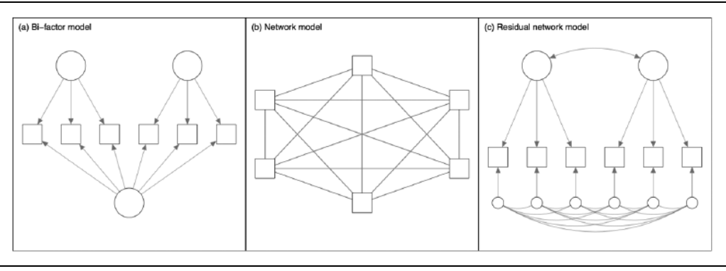

- 1. 双因子モデル、(b) ネットワークモデル、(c) 残差ネットワークモデル は、互いに等価になりうる (van Bork et al., 2017, fig. 2)
- → 双因子モデルがよく当てはまっても、それだけでは一般因子が実在する証拠にならない

## デモ：ネットワークからも「一般因子」は出る

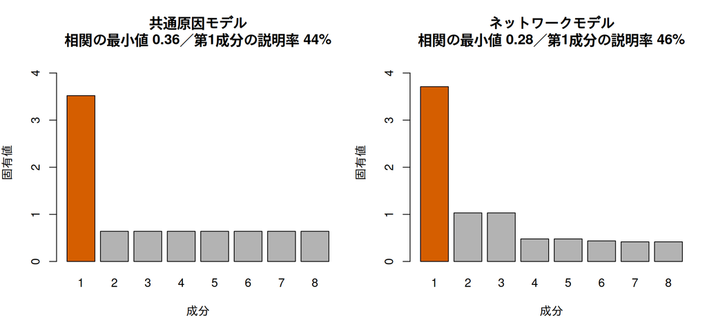

- どちらのモデルでも、すべての相関が正になり、**第1成分が突出する**（データからは区別しにくい）

## 適合度と双因子モデルの問題

- 双因子モデルは柔軟すぎて、どんなデータにもよく当てはまる (Bonifay et al., 2017)
- シミュレーションでは、すべての適合度指標が双因子モデルを過度に有利に評価した（**pro-bifactor バイアス**）(Greene et al., 2019)
  - HiTOP の中核メンバーも共著した、自己点検的な研究
- モデルの適合は、モデルの質を測る指標として当てにならない (Greene et al., 2022)
- 共通因子モデルで生成されていないデータに因子モデルを当てはめると、適合が良くても構成概念間の関係が大きく歪む (Rhemtulla et al., 2020)

## p は部分の和にすぎない（今のところ）

- NESARC データで、p因子得点は**診断数の単純な合計とほぼ同じ**だった (Fried, Greene, et al., 2021)
  - 内在化・外在化の因子得点も同様
- p を「根底にある原因」とみなす実質的な根拠は、現状では乏しい
- 双因子モデルの一般因子と外部変数との相関から「p の正体」を定義する方法にも、解釈上の問題がある (Dolan & Borsboom, 2023)

## p因子研究の5つの問題

Watts et al. (2024) による、現時点で最も包括的な p因子批判

1. 適合度の良さを妥当性と取り違えている
2. p の理論が弱く、構成概念妥当化が不十分
3. 一般因子の再現性が低い
4. 潜在変数モデルの仮定に違反している
5. p を因果的な実体として**物象化**している
- 統計モデルの性質を踏まえて理論を作るべき (Watts et al., 2020)

## 新しい批判：nomorbidity

- 上位次元間の共変動は**併存**ではなく、**症状がほとんどない人々（nomorbidity）**が作っている (Watts et al., 2026)
- データ：ABCD 研究（N = 11,868、9〜10歳から4時点）、養育者評定の CBCL
  - 第1時点では81%が内在化・外在化ともに非臨床域。両方が要注意域以上なのは5.3%だけ (Watts et al., 2026, fig. 1)
- 方法：ベイズ変化点モデル（負の二項回帰）で、内在化と外在化の関係が**どこで変わるか**を推定した

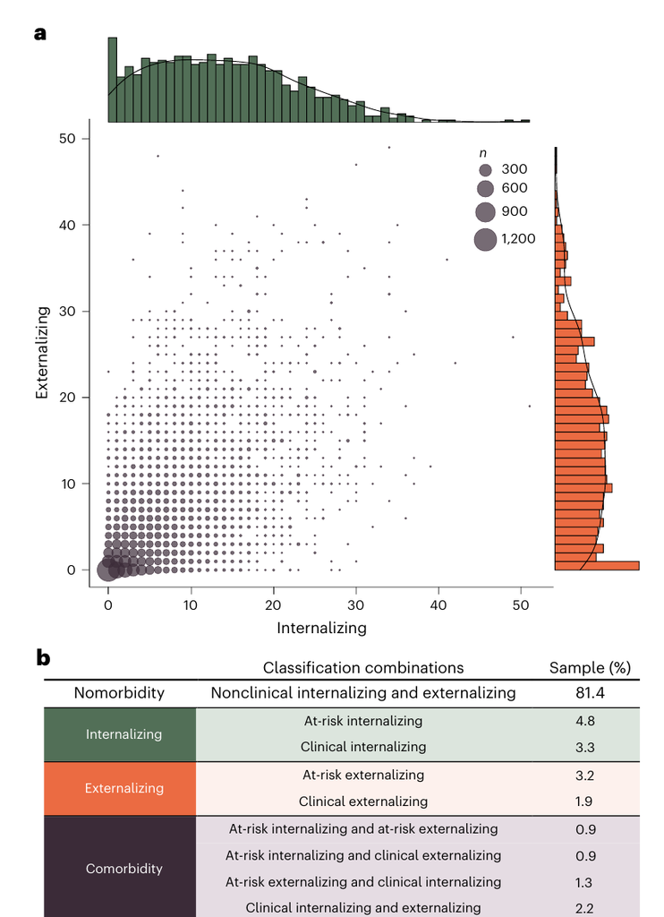

## nomorbidity：結果

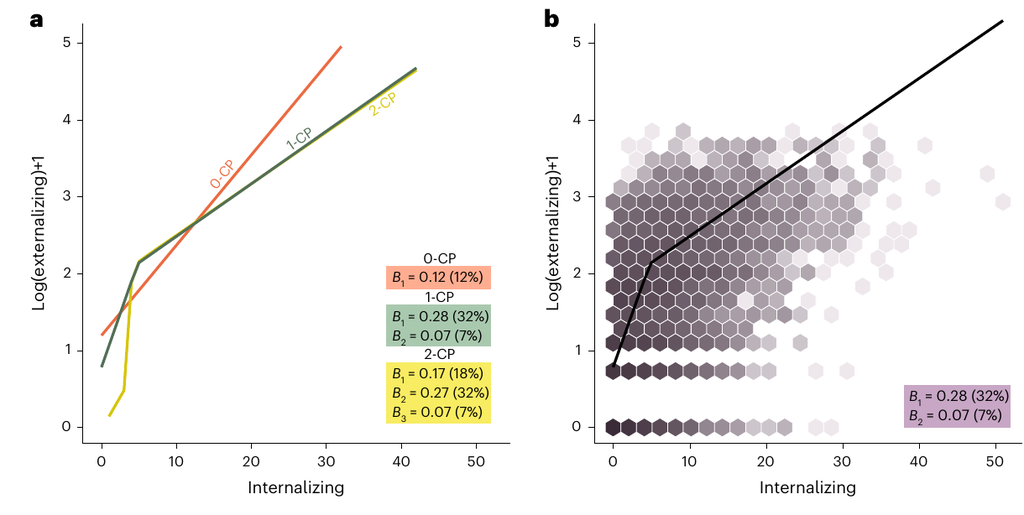

- 変化点は非常に低い水準（内在化得点 4.85、症状2〜3個程度）
- 変化点より前：内在化1点の増加に外在化**32%**の増加（B = 0.28）。変化点より後：**7%**だけ（B = 0.07） (Watts et al., 2026, fig. 2a, b)
- a の 0-CP（変化点なしの線形モデル）は2つの傾きの平均になり、臨床域での関連を過大に予測する

## 変化点を考慮すると予測はどう変わるか

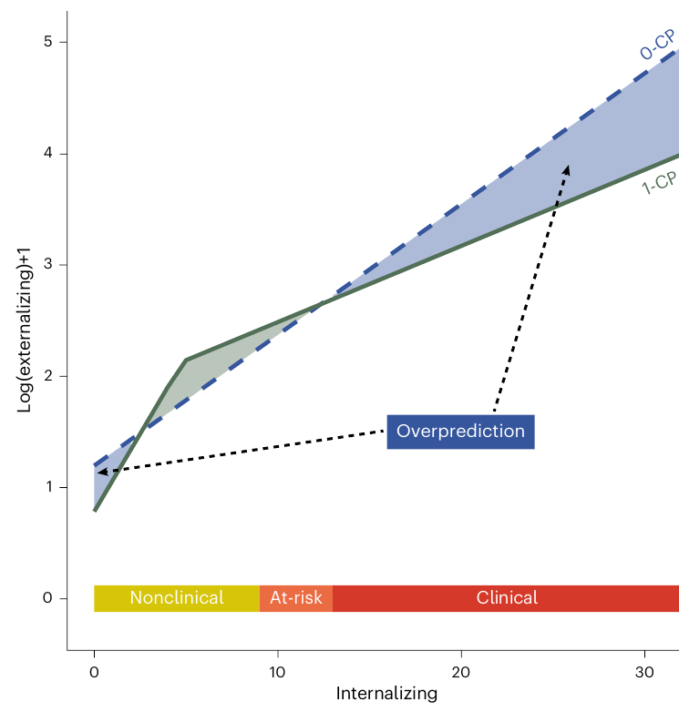

- 横軸は内在化、縦軸は外在化。青の破線は変化点なし、緑の実線は変化点ありの予測。高得点域で予測の差が広がる (Watts et al., 2026, fig. 3)。

## nomorbidity：含意

- 予測変数と基準変数の入れ替え、4時点すべて、他の次元の組み合わせ、成人データでも同じ傾向
- 重症域で関連が再び強まる箇所はなかった
- 通常の線形モデルは2つの傾きを平均するので、**臨床域での関連を過大に予測する**
- → p因子は臨床的な水準の精神病理にはほとんど関係せず、「臨床的な症状がないこと」を反映している可能性
  - 知能の g の「収穫逓減則」と同じ型の現象
- **注意**：無症状者を含めるとネットワークも密になる。この批判は地域サンプルの症状ネットワークにも及ぶ (Watts et al., 2026)

## 目次

- 問題設定：なぜ「構造」が問題になるのか
- 階層モデル：HiTOP・p因子・CB5T
- 心理ネットワークモデル
- 論争：ネットワーク側からの批判
- 論争：階層モデル側からの批判と往復 👈️
- 等価性と実証的な比較
- 統合と収束、そして議論

## 再現性論争の発端

- 2つの疫学データで、うつ・不安の症状ネットワークの構造や中心性は**再現されにくい** (Forbes et al., 2017a)
  - 著者は全員 HiTOP の中核メンバー
- 周辺度数を固定した帰無分布と比べると、推定されたパラメータの多くは偶然と区別できない (Steinley et al., 2017)
- 2017年の *Journal of Abnormal Psychology* 誌上で、批判・反論・再反論が行われた (Borsboom et al., 2017; Forbes et al., 2017b)

## ネットワーク側の反論：False alarm?

- Forbes et al. (2017) のデータを再分析し、適切な推定法を使えばネットワークは**よく再現される**と反論した (Borsboom et al., 2017)
- ベイズ的に再分析すると、再現を支持する証拠が多く、違いの多くは**標本変動の範囲内**だった (Jones et al., 2021)
- 点推定どうしを比べて「再現されない」とするのは不適切で、推定の不確かさを考慮すべき (Fried, van Borkulo, et al., 2021)

## 再反論は続く

- ネットワーク特性（エッジ・中心性）の信頼性と再現性を定量化すると、多くの指標が不安定だった (Forbes et al., 2021b)
- パラメータの推定が不確かな以上、ネットワークから導いた推論は再現されない (Forbes et al., 2021a)
- 「約束 vs 現実」：因果構造の解明や介入標的の特定は、横断データの偏相関ネットワークでは実現していない (Forbes et al., 2019)

## 中心性 ≒ 因子負荷量

- 潜在変数があるデータでは、ノードの強度（strength）は**因子負荷量とほぼ冗長**になる (Hallquist et al., 2021)
- 症状データには潜在変数（HiTOP のスペクトラムのような共通原因）がある可能性が高い
- → 中心性を解釈する前に、潜在構造を検討すべき
  - 副題 “Why network psychometrics cannot escape psychometric theory”
- ネットワーク研究者自身も、社会ネットワーク由来の中心性は心理ネットワークでは解釈しにくいと指摘している (Bringmann et al., 2019)

## 中心性を予測するのは因子負荷量

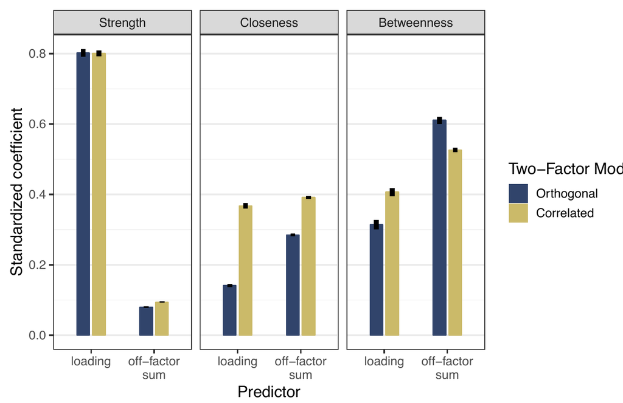

- 2因子モデルからデータを生成し、ノードの中心性を、因子負荷量（loading）と他因子の項目とのつながり（off-factor sum）で予測した
- **強度（strength）はほぼ因子負荷量だけで決まる**（標準化係数 ≈ .8） (Hallquist et al., 2021, fig. 3)

## 方法論としての批判

- ネットワーク分析の標準的な解説 (Borsboom et al., 2021) への批判 (Neal et al., 2022)
  - モデル選択、研究デザイン、推定の信頼性、指標の解釈という4点で、深刻な批判が十分に扱われていない
- ネットワーク側の応答：指摘された問題の多くはネットワーク法に固有ではなく、統計モデル一般に当てはまる (Borsboom, Deserno, et al., 2022)
- 論争点の総括 (McNally, 2021)

## 「モデルのせいにするな」

- 潜在変数モデル自体には本質的な欠陥はない、という議論 (Bringmann & Eronen, 2018)
  - ネットワーク論は、潜在変数モデルの問題を誇張している
  - 両モデルの境界も明確ではない
- ネットワーク論は潜在変数モデルを実在論に限って批判しており、一面的だという認識論的な議論 (Guyon et al., 2017)
- ネットワーク側の自己点検：潜在変数との関係、重要な変数の見落とし、横断データの限界 (Fried & Cramer, 2017)

## HiTOP・p因子側の応答と擁護

- 階層モデルには、遺伝・神経・予後に関する実証的な支持がある (Lahey et al., 2021; Smith et al., 2020)
- p因子の提唱者による、競合モデルの比較と p の解釈の再検討 (Caspi et al., 2024)
- HiTOP の次元を、因果的実体ではなく**実用的・記述的な分類**として位置づける (Krueger, 2025)

## 別の方向からの HiTOP 批判

- HiTOP は症状の見かけの類似性（「クジラとサメ」のような通俗的分類）と、因子回転などの分析上の選択に依存している (Haeffel, Jeronimus, Kaiser, et al., 2022)
- HiTOP 側の応答：外的妥当性と臨床的有用性の証拠を示した (DeYoung et al., 2022)
- 再反論：単純構造の因子分析では症状空間を適切に表せない。HiTOP が DSM より臨床で優れているという証拠はない (Haeffel, Jeronimus, Fisher, et al., 2022)

## 目次

- 問題設定：なぜ「構造」が問題になるのか
- 階層モデル：HiTOP・p因子・CB5T
- 心理ネットワークモデル
- 論争：ネットワーク側からの批判
- 論争：階層モデル側からの批判と往復
- 等価性と実証的な比較 👈️
- 統合と収束、そして議論

## 2つのモデルは統計的に等価になりうる

- Ising ネットワークモデル、多次元 IRT モデル、共通効果モデルは**統計的に等価**になりうる (Kruis & Maris, 2016; Marsman et al., 2018)
- → データへの当てはまりだけでは、どちらの理論が正しいか決められない
- ただし、等価でも制約の解釈が異なるので、データ生成のメカニズムとしてのもっともらしさは別問題。両者は検証で区別できる (van Bork et al., 2021)
- ネットワーク負荷量は、因子負荷量と同じように潜在構造を回復できる (Christensen & Golino, 2021)

## 等価性の解釈は陣営で異なる

|  | ネットワーク側 | 階層モデル側 |
| --- | --- | --- |
| 等価性から言えること | 因子モデルの適合は共通原因の証拠にならない | 潜在変数を無視したネットワークは誤解を招く |
| 次にすべきこと | 理論から異なる予測を導いて検証する | 中心性の前に潜在構造を検討する |

→ どちらの側も「データモデルを理論と取り違えている」と批判されうる (Fried, 2020; Haslbeck et al., 2022)

## 共通原因説 vs 相互作用説を縦断データで比べる

- 相互作用説（dynamic mutualism）の予測：発達とともに症状間の相互作用が強まり、**p の説明力が増す**
- p分化説の予測：発達とともに p の説明力が減り、特異化する

| 研究 | 主な結果 |
| --- | --- |
| Murray et al. (2016) | 7〜15歳で p の説明率はほぼ一定。どちらの説も支持されず |
| McElroy et al. (2018) | 2〜14歳で一般因子の共通分散説明率は61〜71%。一般因子と特異因子の縦断的関連は両説と整合 |
| Gluschkoff et al. (2019) | 双因子構造は10年間安定し、個人内の変化にも当てはまる |
| Choate et al. (2023) | 3つの手法すべてで、相互作用説を予備的に支持 |
| Aristodemou et al. (2024) | 青年期の p の変化には相互作用モデルの適合が良かったが、領域間で正の影響が優勢という予測は支持されなかった |

## 知能での同型の検証

- 確認的な枠組みでネットワークモデルと g因子モデルを比べると、3つのデータセットすべてで**ネットワークモデルの適合が上回った** (Kan et al., 2019)
- ただし、適合の比較だけでは決着しないのは前述のとおり
- 精神病理でも知能でも、「一般因子は共通原因か、相互作用の産物か」という同じ構図の問い

## 目次

- 問題設定：なぜ「構造」が問題になるのか
- 階層モデル：HiTOP・p因子・CB5T
- 心理ネットワークモデル
- 論争：ネットワーク側からの批判
- 論争：階層モデル側からの批判と往復
- 等価性と実証的な比較
- 統合と収束、そして議論 👈️

## 2つを組み合わせるモデル

- 一般化ネットワーク心理測定 (Epskamp et al., 2017)
  - **潜在ネットワークモデル**：潜在変数どうしのネットワーク（HiTOP のスペクトラム間のつながり）
  - **残差ネットワークモデル**：潜在変数で説明しきれない症状どうしの直接のつながり
- 探索的グラフ分析（EGA）：ネットワークのコミュニティ検出で次元数を推定する (Golino & Epskamp, 2017)
- → 「潜在変数か、ネットワークか」の二者択一ではなくなりつつある

## 4つのモデリングの枠組み

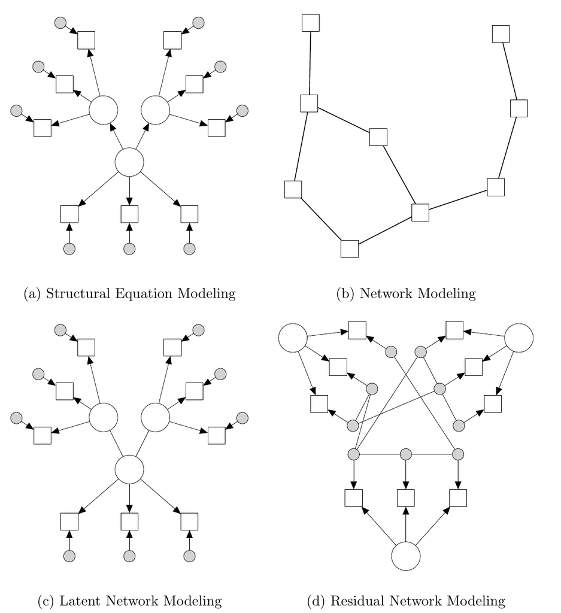

- 1. 構造方程式モデル：潜在変数が観測変数を説明する
- 2. ネットワークモデル：観測変数どうしの直接の相互作用
- 3. 潜在ネットワークモデル：潜在変数どうしをネットワークでつなぐ
- 4. 残差ネットワークモデル：潜在変数で説明しきれない残差どうしをつなぐ
- 丸 ＝ 潜在変数、四角 ＝ 観測変数、灰色 ＝ 残差 (Epskamp et al., 2017, fig. 2)

## 両陣営の共著による収束

- HiTOP、ネットワーク、臨床病期モデルの強み・限界・重なりを比べ、補完的に使う道を示した (Eaton et al., 2023)
  - Krueger、Kotov、Forbes（HiTOP）と Fried、Bringmann（ネットワーク）の共著
- 診断ではなく症状レベルの細かい単位で研究すべき (Forbes, Fried, et al., 2023)
- DSM の症状からデータ駆動で精神病理の構造を作り直す (Forbes et al., 2024)
- HiTOP は高次の潜在因子を探し、システム論は潜在因子の実在について「デフレ的」な立場を取る、という相違 (Rief et al., 2023)

## 症状から作り直した精神病理の階層

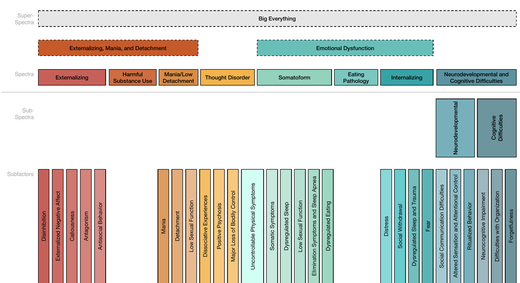

- DSM の診断ではなく個々の症状からデータ駆動で構造を推定した。最上位は「Big Everything」（一般因子に相当） (Forbes et al., 2024, p. プレプリント版の図2)
- HiTOP の中核メンバー（Forbes, Kotov, Krueger）による、「診断単位の因子分析」という批判への応答とも読める

## 残る相違点

| 争点 | ネットワーク側 | 階層モデル側 |
| --- | --- | --- |
| 存在論 | 障害は症状間の相互作用から創発する | 次元・階層は共変動の有用な要約（近年は記述的と位置づけ） |
| p因子の意味 | 正の相関から共通成分が得られる。診断数を超える予測力があるかが争点 | 予後・遺伝・神経との関連という外的妥当性がある |
| モデル選択 | 適合の良さは妥当性の証拠にならない | （適合度バイアスは認める方向） |
| ネットワーク法 | 適切な推定と不確かさの評価で再現される | 再現性が低く、中心性は因子負荷と冗長 |

## 論争から見えてくること

- **統計モデルと理論は別物**：因子モデルもネットワークモデルも「データモデル」であり、メカニズムの理論ではない (Fried, 2020; Haslbeck et al., 2022)
- **適合では決着しない**：等価性があるので、理論から異なる予測を導いて検証する必要がある
- **サンプルの構成が結論を左右する**：ABCD 研究では、内在化と外在化の関連は低得点域で最も強かった (Watts et al., 2026)
- **個人間と個人内は違う**：集団の構造から個人のメカニズムは読み取れない (Borsboom et al., 2003)
- → 形式理論（数理モデル）の構築へ (Haslbeck et al., 2022; Robinaugh et al., 2020)

## 議論のために

1. あなたの研究や臨床の問いには、どちらのモデルが向いているか？
   - 予後の予測、スクリーニング、介入標的の選択、発症のメカニズム
2. p因子や Big Five は「実在する原因」か、「便利な要約」か？ その違いは研究の進め方を変えるか？
3. CB5T のように機能から説明する階層モデルは、ネットワーク側の批判に答えられるか？
4. 地域サンプルと臨床サンプルで構造が違うなら、どちらの構造を「精神病理の構造」と呼ぶべきか？
5. 横断データのネットワーク分析から、何が言えて、何が言えないか？

## まとめ

- **階層モデル**（HiTOP、p因子、Big Five / CB5T）：症状の共変動を次元と階層で要約する。予測と分類に強い
- **ネットワークモデル**：症状どうしの相互作用から障害が生じると考える。メカニズムの仮説づくりに強い
- **論争**：一般因子は原因か統計的な産物か、ネットワークは再現されるか、という往復が続いた
- **現在**：統計的な等価性が認められ、両陣営の共著による統合の動きが進んでいる
- **これから**：データモデルを超えて、検証可能な理論を作ること

## 引用文献

Aristodemou, M. E., Kievit, R. A., Murray, A. L., Eisner, M., Ribeaud, D., & Fried, E. I. (2024). Common cause versus dynamic mutualism: An empirical comparison of two theories of psychopathology in two large longitudinal cohorts. *Clinical Psychological Science*, *12*(3), 380–402. https://doi.org/10.1177/21677026231162814

Bonifay, W., Lane, S. P., & Reise, S. P. (2017). Three concerns with applying a bifactor model as a structure of psychopathology. *Clinical Psychological Science*, *5*(1), 184–186. https://doi.org/10.1177/2167702616657069

Borsboom, D. (2005). *Measuring the mind: Conceptual issues in contemporary psychometrics*. Cambridge University Press. https://doi.org/10.1017/CBO9780511490026

Borsboom, D. (2017). A network theory of mental disorders. *World Psychiatry*, *16*(1), 5–13. https://doi.org/10.1002/wps.20375

Borsboom, D., & Cramer, A. O. J. (2013). Network analysis: An integrative approach to the structure of psychopathology. *Annual Review of Clinical Psychology*, *9*(1), 91–121. https://doi.org/10.1146/annurev-clinpsy-050212-185608

Borsboom, D., Cramer, A. O. J., Schmittmann, V. D., Epskamp, S., & Waldorp, L. J. (2011). The small world of psychopathology. *PLoS ONE*, *6*(11), e27407. https://doi.org/10.1371/journal.pone.0027407

Borsboom, D., Deserno, M. K., Rhemtulla, M., Epskamp, S., Fried, E. I., McNally, R. J., Robinaugh, D. J., Perugini, M., Dalege, J., Costantini, G., Isvoranu, A.-M., Wysocki, A. C., van Borkulo, C. D., van Bork, R., & Waldorp, L. J. (2021). Network analysis of multivariate data in psychological science. *Nature Reviews Methods Primers*, *1*(1). https://doi.org/10.1038/s43586-021-00055-w

Borsboom, D., Deserno, M. K., Rhemtulla, M., Epskamp, S., Fried, E. I., McNally, R. J., Robinaugh, D. J., Perugini, M., Dalege, J., Costantini, G., Isvoranu, A.-M., Wysocki, A. C., van Borkulo, C. D., van Bork, R., & Waldorp, L. J. (2022). Reply to “critiques of network analysis of multivariate data in psychological science.” *Nature Reviews Methods Primers*, *2*(1). https://doi.org/10.1038/s43586-022-00178-8

Borsboom, D., Fried, E. I., Epskamp, S., Waldorp, L. J., van Borkulo, C. D., van der Maas, H. L. J., & Cramer, A. O. J. (2017). False alarm? A comprehensive reanalysis of “evidence that psychopathology symptom networks have limited replicability” by forbes, wright, markon, and krueger (2017). *Journal of Abnormal Psychology*, *126*(7), 989–999. https://doi.org/10.1037/abn0000306

Borsboom, D., Haslbeck, J. M. B., & Robinaugh, D. J. (2022). Systems‐based approaches to mental disorders are the only game in town. *World Psychiatry*, *21*(3), 420–422. https://doi.org/10.1002/wps.21004

Borsboom, D., Mellenbergh, G. J., & van Heerden, J. (2003). The theoretical status of latent variables. *Psychological Review*, *110*(2), 203–219. https://doi.org/10.1037/0033-295x.110.2.203

Boschloo, L., van Borkulo, C. D., Rhemtulla, M., Keyes, K. M., Borsboom, D., & Schoevers, R. A. (2015). The network structure of symptoms of the diagnostic and statistical manual of mental disorders. *PloS One*, *10*(9), e0137621.

Bringmann, L. F., Elmer, T., Epskamp, S., Krause, R. W., Schoch, D., Wichers, M., Wigman, J. T. W., & Snippe, E. (2019). What do centrality measures measure in psychological networks? *Journal of Abnormal Psychology*, *128*(8), 892–903. https://doi.org/10.1037/abn0000446

Bringmann, L. F., & Eronen, M. I. (2018). Don’t blame the model: Reconsidering the network approach to psychopathology. *Psychological Review*, *125*(4), 606–615. https://doi.org/10.1037/rev0000108

Caspi, A., Houts, R. M., Belsky, D. W., Goldman-Mellor, S. J., Harrington, H., Israel, S., Meier, M. H., Ramrakha, S., Shalev, I., Poulton, R., & Moffitt, T. E. (2014). The p factor: One general psychopathology factor in the structure of psychiatric disorders? *Clinical Psychological Science*, *2*(2), 119–137. https://doi.org/10.1177/2167702613497473

Caspi, A., Houts, R. M., Fisher, H. L., Danese, A., & Moffitt, T. E. (2024). The general factor of psychopathology (p): Choosing among competing models and interpreting p. *Clinical Psychological Science*, *12*(1), 53–82. https://doi.org/10.1177/21677026221147872

Caspi, A., & Moffitt, T. E. (2018). All for one and one for all: Mental disorders in one dimension. *American Journal of Psychiatry*, *175*(9), 831–844. https://doi.org/10.1176/appi.ajp.2018.17121383

Choate, A. M., Bornovalova, M. A., Hipwell, A. E., Chung, T., & Stepp, S. D. (2023). The general psychopathology factor (p) from adolescence to adulthood: Exploring the developmental trajectories of p using a multi-method approach. *Development and Psychopathology*, *35*(4), 1775–1793. https://doi.org/10.1017/s0954579422000463

Christensen, A. P., & Golino, H. (2021). On the equivalency of factor and network loadings. *Behavior Research Methods*, *53*(4), 1563–1580. https://doi.org/10.3758/s13428-020-01500-6

Christensen, A. P., Golino, H., & Silvia, P. J. (2020). A psychometric network perspective on the validity and validation of personality trait questionnaires. *European Journal of Personality*, *34*(6), 1095–1108. https://doi.org/10.1002/per.2265

Conway, C. C., Forbes, M. K., Forbush, K. T., Fried, E. I., Hallquist, M. N., Kotov, R., Mullins-Sweatt, S. N., Shackman, A. J., Skodol, A. E., South, S. C., Sunderland, M., Waszczuk, M. A., Zald, D. H., Afzali, M. H., Bornovalova, M. A., Carragher, N., Docherty, A. R., Jonas, K. G., Krueger, R. F., … Eaton, N. R. (2019). A hierarchical taxonomy of psychopathology can transform mental health research. *Perspectives on Psychological Science*, *14*(3), 419–436. https://doi.org/10.1177/1745691618810696

Costantini, G., Epskamp, S., Borsboom, D., Perugini, M., Mõttus, R., Waldorp, L. J., & Cramer, A. O. J. (2015). State of the aRt personality research: A tutorial on network analysis of personality data in r. *Journal of Research in Personality*, *54*, 13–29. https://doi.org/10.1016/j.jrp.2014.07.003

Cramer, A. O. J., Van Der Sluis, S., Noordhof, A., Wichers, M., Geschwind, N., Aggen, S. H., Kendler, K. S., & Borsboom, D. (2012a). Dimensions of normal personality as networks in search of equilibrium: You can’t like parties if you don’t like people. *European Journal of Personality*, *26*(4), 414–431. https://doi.org/10.1002/per.1866

Cramer, A. O. J., Van Der Sluis, S., Noordhof, A., Wichers, M., Geschwind, N., Aggen, S. H., Kendler, K. S., & Borsboom, D. (2012b). Measurable like temperature or mereological like flocking? On the nature of personality traits. *European Journal of Personality*, *26*(4), 451–459. https://doi.org/10.1002/per.1879

Cramer, A. O. J., Waldorp, L. J., van der Maas, H. L. J., & Borsboom, D. (2010). Comorbidity: A network perspective. *Behavioral and Brain Sciences*, *33*(2-3), 137–150. https://doi.org/10.1017/s0140525x09991567

DeYoung, C. G. (2006). Higher-order factors of the big five in a multi-informant sample. *Journal of Personality and Social Psychology*, *91*(6), 1138–1151. https://doi.org/10.1037/0022-3514.91.6.1138

DeYoung, C. G. (2015). Cybernetic big five theory. *Journal of Research in Personality*, *56*, 33–58. https://doi.org/10.1016/j.jrp.2014.07.004

DeYoung, C. G., Kotov, R., Krueger, R. F., Cicero, D. C., Conway, C. C., Eaton, N. R., Forbes, M. K., Hallquist, M. N., Jonas, K. G., Latzman, R. D., Rodriguez-Seijas, C., Ruggero, C. J., Simms, L. J., Waldman, I. D., Waszczuk, M. A., Widiger, T. A., & Wright, A. G. C. (2022). Answering questions about the hierarchical taxonomy of psychopathology (HiTOP): Analogies to whales and sharks miss the boat. *Clinical Psychological Science*, *10*(2), 279–284. https://doi.org/10.1177/21677026211049390

DeYoung, C. G., & Krueger, R. F. (2018). A cybernetic theory of psychopathology. *Psychological Inquiry*, *29*(3), 117–138. https://doi.org/10.1080/1047840x.2018.1513680

Digman, J. M. (1997). Higher-order factors of the big five. *Journal of Personality and Social Psychology*, *73*(6), 1246–1256. https://doi.org/10.1037/0022-3514.73.6.1246

Dolan, C. V., & Borsboom, D. (2023). Interpretational issues with the bifactor model: A commentary on “defining the p-factor: An empirical test of five leading theories” by southward, cheavens, and coccaro. *Psychological Medicine*, *53*(7), 2744–2747. https://doi.org/10.1017/s0033291723000533

Eaton, N. R., Bringmann, L. F., Elmer, T., Fried, E. I., Forbes, M. K., Greene, A. L., Krueger, R. F., Kotov, R., McGorry, P. D., Mei, C., & Waszczuk, M. A. (2023). A review of approaches and models in psychopathology conceptualization research. *Nature Reviews Psychology*, *2*(10), 622–636. https://doi.org/10.1038/s44159-023-00218-4

Epskamp, S., Borsboom, D., & Fried, E. I. (2018). Estimating psychological networks and their accuracy: A tutorial paper. *Behavior Research Methods*, *50*(1), 195–212. https://doi.org/10.3758/s13428-017-0862-1

Epskamp, S., Rhemtulla, M., & Borsboom, D. (2017). Generalized network psychometrics: Combining network and latent variable models. *Psychometrika*, *82*(4), 904–927. https://doi.org/10.1007/s11336-017-9557-x

Forbes, M. K., Baillie, A., Batterham, P. J., Calear, A., Kotov, R., Krueger, R. F., Markon, K. E., Mewton, L., Pellicano, E., Roberts, M., Rodriguez-Seijas, C., Sunderland, M., Watson, D., Watts, A. L., Wright, A. G. C., & Clark, L. A. (2024). Reconstructing psychopathology: A data-driven reorganization of the symptoms in the diagnostic and statistical manual of mental disorders. *Clinical Psychological Science*, *13*(3), 462–488. https://doi.org/10.1177/21677026241268345

Forbes, M. K., Fried, E. I., & Vaidyanathan, U. (2023). Studying fine-grained elements of psychopathology to advance mental health science. *Journal of Psychopathology and Clinical Science*, *132*(7), 793–796. https://doi.org/10.1037/abn0000872

Forbes, M. K., Neo, B., Nezami, O. M., Fried, E. I., Faure, K., Michelsen, B., Twose, M., & Dras, M. (2023). Elemental psychopathology: Distilling constituent symptoms and patterns of repetition in the diagnostic criteria of the DSM-5. *Psychological Medicine*, *54*(5), 886–894. https://doi.org/10.1017/s0033291723002544

Forbes, M. K., Wright, A. G. C., Markon, K. E., & Krueger, R. F. (2017a). Evidence that psychopathology symptom networks have limited replicability. *Journal of Abnormal Psychology*, *126*(7), 969–988. https://doi.org/10.1037/abn0000276

Forbes, M. K., Wright, A. G. C., Markon, K. E., & Krueger, R. F. (2017b). Further evidence that psychopathology networks have limited replicability and utility: Response to borsboom et al. (2017) and steinley et al. (2017). *Journal of Abnormal Psychology*, *126*(7), 1011–1016. https://doi.org/10.1037/abn0000313

Forbes, M. K., Wright, A. G. C., Markon, K. E., & Krueger, R. F. (2019). The network approach to psychopathology: Promise versus reality. *World Psychiatry*, *18*(3), 272–273. https://doi.org/10.1002/wps.20659

Forbes, M. K., Wright, A. G. C., Markon, K. E., & Krueger, R. F. (2021a). On unreplicable inferences in psychopathology symptom networks and the importance of unreliable parameter estimates. *Multivariate Behavioral Research*, *56*(2), 368–376. https://doi.org/10.1080/00273171.2021.1886897

Forbes, M. K., Wright, A. G. C., Markon, K. E., & Krueger, R. F. (2021b). Quantifying the reliability and replicability of psychopathology network characteristics. *Multivariate Behavioral Research*, *56*(2), 224–242. https://doi.org/10.1080/00273171.2019.1616526

Fried, E. I. (2015). Problematic assumptions have slowed down depression research: Why symptoms, not syndromes are the way forward. *Frontiers in Psychology*, *6*. https://doi.org/10.3389/fpsyg.2015.00309

Fried, E. I. (2020). Lack of theory building and testing impedes progress in the factor and network literature. *Psychological Inquiry*, *31*(4), 271–288. https://doi.org/10.1080/1047840x.2020.1853461

Fried, E. I., & Cramer, A. O. J. (2017). Moving forward: Challenges and directions for psychopathological network theory and methodology. *Perspectives on Psychological Science*, *12*(6), 999–1020. https://doi.org/10.1177/1745691617705892

Fried, E. I., Greene, A. L., & Eaton, N. R. (2021). The p factor is the sum of its parts, for now. *World Psychiatry*, *20*(1), 69–70. https://doi.org/10.1002/wps.20814

Fried, E. I., & Robinaugh, D. J. (2020). Systems all the way down: Embracing complexity in mental health research. *BMC Medicine*, *18*(1). https://doi.org/10.1186/s12916-020-01668-w

Fried, E. I., van Borkulo, C. D., & Epskamp, S. (2021). On the importance of estimating parameter uncertainty in network psychometrics: A response to forbes et al. (2019). *Multivariate Behavioral Research*, *56*(2), 243–248. https://doi.org/10.1080/00273171.2020.1746903

Gluschkoff, K., Jokela, M., & Rosenström, T. (2019). The general psychopathology factor: Structural stability and generalizability to within-individual changes. *Frontiers in Psychiatry*, *10*. https://doi.org/10.3389/fpsyt.2019.00594

Golino, H. F., & Epskamp, S. (2017). Exploratory graph analysis: A new approach for estimating the number of dimensions in psychological research. *PLOS ONE*, *12*(6), e0174035. https://doi.org/10.1371/journal.pone.0174035

Greene, A. L., Eaton, N. R., Forbes, M. K., Fried, E. I., Watts, A. L., Kotov, R., & Krueger, R. F. (2022). Model fit is a fallible indicator of model quality in quantitative psychopathology research: A reply to bader and moshagen. *Journal of Psychopathology and Clinical Science*, *131*(6), 696–703. https://doi.org/10.1037/abn0000770

Greene, A. L., Eaton, N. R., Li, K., Forbes, M. K., Krueger, R. F., Markon, K. E., Waldman, I. D., Cicero, D. C., Conway, C. C., Docherty, A. R., Fried, E. I., Ivanova, M. Y., Jonas, K. G., Latzman, R. D., Patrick, C. J., Reininghaus, U., Tackett, J. L., Wright, A. G. C., & Kotov, R. (2019). Are fit indices used to test psychopathology structure biased? A simulation study. *Journal of Abnormal Psychology*, *128*(7), 740–764. https://doi.org/10.1037/abn0000434

Grosz, M. P. (2026). Why the big five personality traits are composites, not common causes: Implications for measurement, prediction, and causal inference. *Psychological Review*. https://doi.org/10.1037/rev0000637

Guyon, H., Falissard, B., & Kop, J.-L. (2017). Modeling psychological attributes in psychology – an epistemological discussion: Network analysis vs. Latent variables. *Frontiers in Psychology*, *8*. https://doi.org/10.3389/fpsyg.2017.00798

Haeffel, G. J., Jeronimus, B. F., Fisher, A. J., Kaiser, B. N., Weaver, L. J., Vargas, I., Goodson, J. T., Soyster, P. D., & Lu, W. (2022). The hierarchical taxonomy of psychopathology (HiTOP) is not an improvement over the DSM. *Clinical Psychological Science*, *10*(2), 285–290. https://doi.org/10.1177/21677026211068873

Haeffel, G. J., Jeronimus, B. F., Kaiser, B. N., Weaver, L. J., Soyster, P. D., Fisher, A. J., Vargas, I., Goodson, J. T., & Lu, W. (2022). Folk classification and factor rotations: Whales, sharks, and the problems with the hierarchical taxonomy of psychopathology (HiTOP). *Clinical Psychological Science*, *10*(2), 259–278. https://doi.org/10.1177/21677026211002500

Hallquist, M. N., Wright, A. G. C., & Molenaar, P. C. M. (2021). Problems with centrality measures in psychopathology symptom networks: Why network psychometrics cannot escape psychometric theory. *Multivariate Behavioral Research*, *56*(2), 199–223. https://doi.org/10.1080/00273171.2019.1640103

Haslbeck, J. M. B., Ryan, O., Robinaugh, D. J., Waldorp, L. J., & Borsboom, D. (2022). Modeling psychopathology: From data models to formal theories. *Psychological Methods*. https://doi.org/10.1037/met0000303

Isvoranu, A.-M., Epskamp, S., Waldorp, L., & Borsboom, D. (2022). *Network psychometrics with r: A guide for behavioral and social scientists*. Taylor & Francis.

Jones, P. J., Williams, D. R., & McNally, R. J. (2021). Sampling variability is not nonreplication: A bayesian reanalysis of forbes, wright, markon, and krueger. *Multivariate Behavioral Research*, *56*(2), 249–255. https://doi.org/10.1080/00273171.2020.1797460

Kan, K.-J., van der Maas, H. L. J., & Levine, S. Z. (2019). Extending psychometric network analysis: Empirical evidence against g in favor of mutualism? *Intelligence*, *73*, 52–62. https://doi.org/10.1016/j.intell.2018.12.004

Kotov, R., Krueger, R. F., Watson, D., Achenbach, T. M., Althoff, R. R., Bagby, R. M., Brown, T. A., Carpenter, W. T., Caspi, A., Clark, L. A., Eaton, N. R., Forbes, M. K., Forbush, K. T., Goldberg, D., Hasin, D., Hyman, S. E., Ivanova, M. Y., Lynam, D. R., Markon, K., … Zimmerman, M. (2017). The hierarchical taxonomy of psychopathology (HiTOP): A dimensional alternative to traditional nosologies. *Journal of Abnormal Psychology*, *126*(4), 454–477. https://doi.org/10.1037/abn0000258

Kotov, R., Krueger, R. F., Watson, D., Cicero, D. C., Conway, C. C., DeYoung, C. G., Eaton, N. R., Forbes, M. K., Hallquist, M. N., Latzman, R. D., Mullins-Sweatt, S. N., Ruggero, C. J., Simms, L. J., Waldman, I. D., Waszczuk, M. A., & Wright, A. G. C. (2021). The hierarchical taxonomy of psychopathology (HiTOP): A quantitative nosology based on consensus of evidence. *Annual Review of Clinical Psychology*, *17*(1), 83–108. https://doi.org/10.1146/annurev-clinpsy-081219-093304

Krueger, R. F. (2025). Recent advances in the conceptualization and evidence supporting the HiTOP approach. *World Psychiatry*, *24*(2), 267–268. https://doi.org/10.1002/wps.21318

Krueger, R. F., Kotov, R., Watson, D., Forbes, M. K., Eaton, N. R., Ruggero, C. J., Simms, L. J., Widiger, T. A., Achenbach, T. M., Bach, B., Bagby, R. M., Bornovalova, M. A., Carpenter, W. T., Chmielewski, M., Cicero, D. C., Clark, L. A., Conway, C., DeClercq, B., DeYoung, C. G., … Zimmermann, J. (2018). Progress in achieving quantitative classification of psychopathology. *World Psychiatry*, *17*(3), 282–293. https://doi.org/10.1002/wps.20566

Kruis, J., & Maris, G. (2016). Three representations of the ising model. *Scientific Reports*, *6*(1). https://doi.org/10.1038/srep34175

Lahey, B. B., Moore, T. M., Kaczkurkin, A. N., & Zald, D. H. (2021). Hierarchical models of psychopathology: Empirical support, implications, and remaining issues. *World Psychiatry*, *20*(1), 57–63. https://doi.org/10.1002/wps.20824

Marsman, M., Borsboom, D., Kruis, J., Epskamp, S., van Bork, R., Waldorp, L. J., Maas, H. L. J. van der, & Maris, G. (2018). An introduction to network psychometrics: Relating ising network models to item response theory models. *Multivariate Behavioral Research*, *53*(1), 15–35. https://doi.org/10.1080/00273171.2017.1379379

McElroy, E., Belsky, J., Carragher, N., Fearon, P., & Patalay, P. (2018). Developmental stability of general and specific factors of psychopathology from early childhood to adolescence: Dynamic mutualism or p ‐differentiation? *Journal of Child Psychology and Psychiatry*, *59*(6), 667–675. https://doi.org/10.1111/jcpp.12849

McNally, R. J. (2021). Network analysis of psychopathology: Controversies and challenges. *Annual Review of Clinical Psychology*, *17*(1), 31–53. https://doi.org/10.1146/annurev-clinpsy-081219-092850

Mõttus, R., Kandler, C., Bleidorn, W., Riemann, R., & McCrae, R. R. (2017). Personality traits below facets: The consensual validity, longitudinal stability, heritability, and utility of personality nuances. *Journal of Personality and Social Psychology*, *112*(3), 474–490. https://doi.org/10.1037/pspp0000100

Murray, A. L., Eisner, M., & Ribeaud, D. (2016). The development of the general factor of psychopathology “p factor” through childhood and adolescence. *Journal of Abnormal Child Psychology*, *44*(8), 1573–1586. https://doi.org/10.1007/s10802-016-0132-1

Neal, Z. P., Forbes, M. K., Neal, J. W., Brusco, M. J., Krueger, R., Markon, K., Steinley, D., Wasserman, S., & Wright, A. G. C. (2022). Critiques of network analysis of multivariate data in psychological science. *Nature Reviews Methods Primers*, *2*(1). https://doi.org/10.1038/s43586-022-00177-9

Rhemtulla, M., van Bork, R., & Borsboom, D. (2020). Worse than measurement error: Consequences of inappropriate latent variable measurement models. *Psychological Methods*, *25*(1), 30–45. https://doi.org/10.1037/met0000220

Rief, W., Hofmann, S. G., Berg, M., Forbes, M. K., Pizzagalli, D. A., Zimmermann, J., Fried, E., & Reed, G. M. (2023). Do we need a novel framework for classifying psychopathology? A discussion paper. *Clinical Psychology in Europe*, *5*(4). https://doi.org/10.32872/cpe.11699

Robinaugh, D. J., Hoekstra, R. H. A., Toner, E. R., & Borsboom, D. (2020). The network approach to psychopathology: A review of the literature 2008–2018 and an agenda for future research. *Psychological Medicine*, *50*(3), 353–366. https://doi.org/10.1017/s0033291719003404

Smith, G. T., Atkinson, E. A., Davis, H. A., Riley, E. N., & Oltmanns, J. R. (2020). The general factor of psychopathology. *Annual Review of Clinical Psychology*, *16*(1), 75–98. https://doi.org/10.1146/annurev-clinpsy-071119-115848

Southward, M. W., Cheavens, J. S., & Coccaro, E. F. (2023). Defining the p -factor: An empirical test of five leading theories. *Psychological Medicine*, *53*(7), 2732–2743. https://doi.org/10.1017/s0033291722001635

Steinley, D., Hoffman, M., Brusco, M. J., & Sher, K. J. (2017). A method for making inferences in network analysis: Comment on forbes, wright, markon, and krueger (2017). *Journal of Abnormal Psychology*, *126*(7), 1000–1010. https://doi.org/10.1037/abn0000308

van Bork, R., Epskamp, S., Rhemtulla, M., Borsboom, D., & van der Maas, H. L. J. (2017). What is the p -factor of psychopathology? Some risks of general factor modeling. *Theory &Amp; Psychology*, *27*(6), 759–773. https://doi.org/10.1177/0959354317737185

van Bork, R., Rhemtulla, M., Waldorp, L. J., Kruis, J., Rezvanifar, S., & Borsboom, D. (2021). Latent variable models and networks: Statistical equivalence and testability. *Multivariate Behavioral Research*, *56*(2), 175–198. https://doi.org/10.1080/00273171.2019.1672515

Van Der Maas, H. L. J., Dolan, C. V., Grasman, R. P. P. P., Wicherts, J. M., Huizenga, H. M., & Raijmakers, M. E. J. (2006). A dynamical model of general intelligence: The positive manifold of intelligence by mutualism. *Psychological Review*, *113*(4), 842–861. https://doi.org/10.1037/0033-295x.113.4.842

Van Der Maas, H., Kan, K.-J., Marsman, M., & Stevenson, C. E. (2017). Network models for cognitive development and intelligence. *Journal of Intelligence*, *5*(2), 16. https://doi.org/10.3390/jintelligence5020016

Watts, A. L., Greene, A. L., Bonifay, W., & Fried, E. I. (2024). A critical evaluation of the p-factor literature. *Nature Reviews Psychology*, *3*(2), 108–122. https://doi.org/10.1038/s44159-023-00260-2

Watts, A. L., Lane, S. P., Bonifay, W., Steinley, D., & Meyer, F. A. C. (2020). Building theories on top of, and not independent of, statistical models: The case of the p-factor. *Psychological Inquiry*, *31*(4), 310–320. https://doi.org/10.1080/1047840x.2020.1853476

Watts, A. L., Rosen, A. F. G., Greene, A. L., King, K. M., Meyer, F. A. C., Trull, T. J., Sher, K. J., & Joyner, K. J. (2026). Covariation among higher-order psychopathology dimensions is driven by nomorbidity and not comorbidity. *Nature Mental Health*, *4*(11), 1674–1685. https://doi.org/10.1038/s44220-026-00727-0

Widiger, T. A., Sellbom, M., Chmielewski, M., Clark, L. A., DeYoung, C. G., Kotov, R., Krueger, R. F., Lynam, D. R., Miller, J. D., Mullins-Sweatt, S., Samuel, D. B., South, S. C., Tackett, J. L., Thomas, K. M., Watson, D., & Wright, A. G. C. (2019). Personality in a hierarchical model of psychopathology. *Clinical Psychological Science*, *7*(1), 77–92. https://doi.org/10.1177/2167702618797105

Wright, A. G. C., & Woods, W. C. (2020). Personalized models of psychopathology. *Annual Review of Clinical Psychology*, *16*(1), 49–74. https://doi.org/10.1146/annurev-clinpsy-102419-125032